# Happy Planet Code-Along

```r
library(tidyverse) #this is the tidyverse package that we almost always use!
```

```r
library(viridisLite) #this package is for adding colorblind-friendly colors to your plots.
```

# Introduction

Before we start in earnest, we need to introduce some basic points about `R` and markdown

## Markdown

A simple markup language for creating text documents.

- Can use basic syntax to create formatted text, such as headings, (with `#`), bullet points, **bolding**, *italics*, and `code_syntax`.
- You can also embed `R` code in text, like `2+2 =` 4
- and embed code chunks and their outputs (creation hotkey: `cmd-option-i`)

## Coding in R

Things we’ll go over …

- Typing commands in the console
- R is dumb
  - Avoid typos (but flexibility with spacing, line breaks)
  - Read left to right
  - Errors happen! Read your error messages. Google them!
- Mathematical operators (`+ - * / ^`)
- Order of operations
- Variable assignment (`<-`) hotkey: `option -` (option and minus at same time)
- Calculations with variables
- Naming variables (rules and conventions)
- Using functions
  - Arguments, named arguments, and defaults
  - E.g. `round()`
  - Piping (`%>%` OR `|>`) hotkey: `shift-ctrl-M` (Mac: `shift-command-M`)
- Tab completion
- Indexing dataframes/tibbles and lists (`$`)
- Comments (`#`)

# Exploratory data analysis

## Questions:

- How much does average happiness vary across countries?
- Which countries are happiest? Which are least happy?
- Can you buy happiness? How does per capita GDP relate to happiness?
- What is the cost of happiness? How does a country’s happiness relate to its ecological footprint?

### Load the Happy Planet Index data frame we will be using.

```r
# source: "https://www.lock5stat.com/datasets3e/HappyPlanetIndex.csv"
# notes to future self: you're smart
happy <- read_csv("data/HappyPlanetIndex.csv")
```

Check out the dataset. What are the variables?

Type `?happy` in the console (recall that we used this last week to get information about our dataset). What happens? Why?

View the dataset by typing `View(happy)` in the console or clicking on the dataset in the Environment pane.

### Let’s clean up our dataset. Assume we want to replace the numbers in the region variable with the actual regions they correspond to. We also want to turn the HDI variable into a categorical variable with 4 levels.

Note: HDI (Human Development Index) measures a country’s average achievements in three key dimensions: health, knowledge, and a decent standard of living.

```r
happy <- happy %>%
  mutate(
    Region = case_when(
      Region == 1 ~ "Latin America",
      Region == 2 ~ "Western",
      Region == 3 ~ "Middle East",
      Region == 4 ~ "SubSaharan Africa",
      Region == 5 ~ "South Asia",
      Region == 6 ~ "East Asia",
      Region == 7 ~ "Former Soviet",
      TRUE ~ NA_character_
    ),
    HDI_group = factor(case_when(
      HDI <= .55 ~ "Low",
      HDI < .699 ~ "Medium",
      HDI < .799 ~ "High",
      HDI >= .799 ~ "Very high",
      is.na(HDI) ~ NA_character_
    ), levels = c("Low","Medium","High","Very high")
  )
  )
```

### Glimpse (i.e., take a quick look) at the data.

We’ll make a code chunk and use “glimpse” for a view we can include in an output notebook.

```r
?glimpse
```

```
## Help on topic 'glimpse' was found in the following packages:
##
##   Package               Library
##   dplyr                 /Library/Frameworks/R.framework/Versions/4.5-arm64/Resources/library
##   tibble                /Library/Frameworks/R.framework/Versions/4.5-arm64/Resources/library
##   pillar                /Library/Frameworks/R.framework/Versions/4.5-arm64/Resources/library
##
##
## Using the first match ...
```

```r
glimpse(happy)
```

```
## Rows: 143
## Columns: 12
## $ Country        <chr> "Albania", "Algeria", "Angola", "Argentina", "Armenia",…
## $ Region         <chr> "Former Soviet", "Middle East", "SubSaharan Africa", "L…
## $ Happiness      <dbl> 5.5, 5.6, 4.3, 7.1, 5.0, 7.9, 7.8, 5.3, 5.3, 5.8, 7.6, …
## $ LifeExpectancy <dbl> 76.2, 71.7, 41.7, 74.8, 71.7, 80.9, 79.4, 67.1, 63.1, 6…
## $ Footprint      <dbl> 2.2, 1.7, 0.9, 2.5, 1.4, 7.8, 5.0, 2.2, 0.6, 3.9, 5.1, …
## $ HLY            <dbl> 41.7, 40.1, 17.8, 53.4, 36.1, 63.7, 61.9, 35.4, 33.1, 4…
## $ HPI            <dbl> 47.91, 51.23, 26.78, 58.95, 48.28, 36.64, 47.69, 41.21,…
## $ HPIRank        <dbl> 54, 40, 130, 15, 48, 102, 57, 85, 31, 104, 64, 27, 134,…
## $ GDPperCapita   <dbl> 5316, 7062, 2335, 14280, 4945, 31794, 33700, 5016, 2053…
## $ HDI            <dbl> 0.801, 0.733, 0.446, 0.869, 0.775, 0.962, 0.948, 0.746,…
## $ Population     <dbl> 3.15, 32.85, 16.10, 38.75, 3.02, 20.40, 8.23, 8.39, 153…
## $ HDI_group      <fct> Very high, High, Low, Very high, High, Very high, Very …
```

### How much does happiness vary across countries?

Let’s create a histogram!

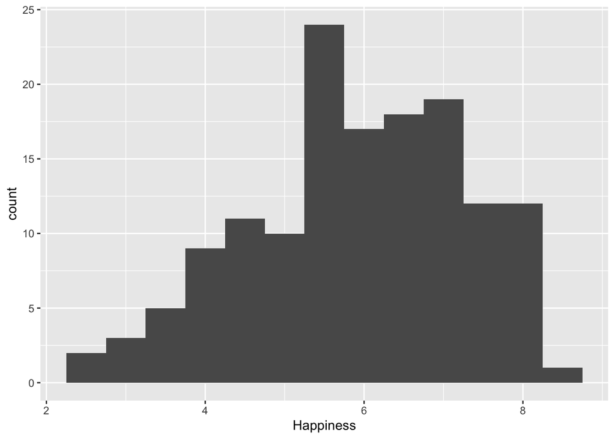

```r
ggplot(happy, aes(x=Happiness)) +
  geom_histogram(binwidth=.5)
```

#### Which are the happiest countries?

Hint: filter for a value that indicates “high” happiness and arrange from highest to lowest.

```r
happy  %>%
  filter(Happiness >= 8)  %>%
  arrange(desc(Happiness))
```

```
## # A tibble: 6 × 12
##   Country    Region       Happiness LifeExpectancy Footprint   HLY   HPI HPIRank
##   <chr>      <chr>            <dbl>          <dbl>     <dbl> <dbl> <dbl>   <dbl>
## 1 Costa Rica Latin Ameri…       8.5           78.5       2.3  66.7  76.1       1
## 2 Denmark    Western            8.1           77.9       8    62.9  35.5     105
## 3 Ireland    Western            8.1           78.4       6.3  63.8  42.6      78
## 4 Norway     Western            8.1           79.8       6.9  64.6  40.4      88
## 5 Canada     Western            8             80.3       7.1  64    39.4      89
## 6 Finland    Western            8             78.9       5.2  63.3  47.2      59
## # ℹ 4 more variables: GDPperCapita <dbl>, HDI <dbl>, Population <dbl>,
## #   HDI_group <fct>
```

#### Which are the least happy countries?

Hint: `head()` gives you the top rows, but you want the bottom rows. Try ?head to see if it gives you suggestions.

```r
happy %>%
  arrange(desc(Happiness)) %>%
  tail()
```

```
## # A tibble: 6 × 12
##   Country      Region     Happiness LifeExpectancy Footprint   HLY   HPI HPIRank
##   <chr>        <chr>          <dbl>          <dbl>     <dbl> <dbl> <dbl>   <dbl>
## 1 Sierra Leone SubSahara…       3.6           41.8       0.8  14.8  23.1     136
## 2 Benin        SubSahara…       3             55.4       1    16.7  24.6     134
## 3 Burundi      SubSahara…       2.9           48.5       0.8  14.3  21.8     139
## 4 Zimbabwe     SubSahara…       2.8           40.9       1.1  11.6  16.6     143
## 5 Togo         SubSahara…       2.6           57.8       0.8  15.2  23.3     135
## 6 Tanzania     SubSahara…       2.4           51         1.1  12.5  17.8     142
## # ℹ 4 more variables: GDPperCapita <dbl>, HDI <dbl>, Population <dbl>,
## #   HDI_group <fct>
```

#### How does happiness vary by region?

Get summary statistics (mean, sd) of Happiness across the different Regions.

```r
happy %>%
  group_by(Region)  %>%
  summarise(Mean_Happiness = mean(Happiness),
            SD_Happiness = sd(Happiness))  %>%
  arrange(Mean_Happiness)
```

```
## # A tibble: 7 × 3
##   Region            Mean_Happiness SD_Happiness
##   <chr>                      <dbl>        <dbl>
## 1 SubSaharan Africa           4.05        0.765
## 2 South Asia                  5.59        0.308
## 3 Former Soviet               5.74        0.579
## 4 Middle East                 5.99        0.855
## 5 East Asia                   6.32        0.671
## 6 Latin America               6.91        0.678
## 7 Western                     7.55        0.524
```

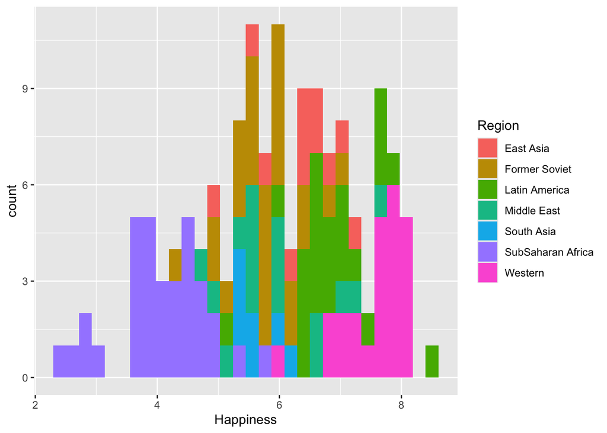

```r
happy %>%
  ggplot(aes(x=Happiness, fill=Region)) +
  geom_histogram()
```

## Can you buy happiness?

Visualize the relation between happiness and GDP. Does this differ by Region?

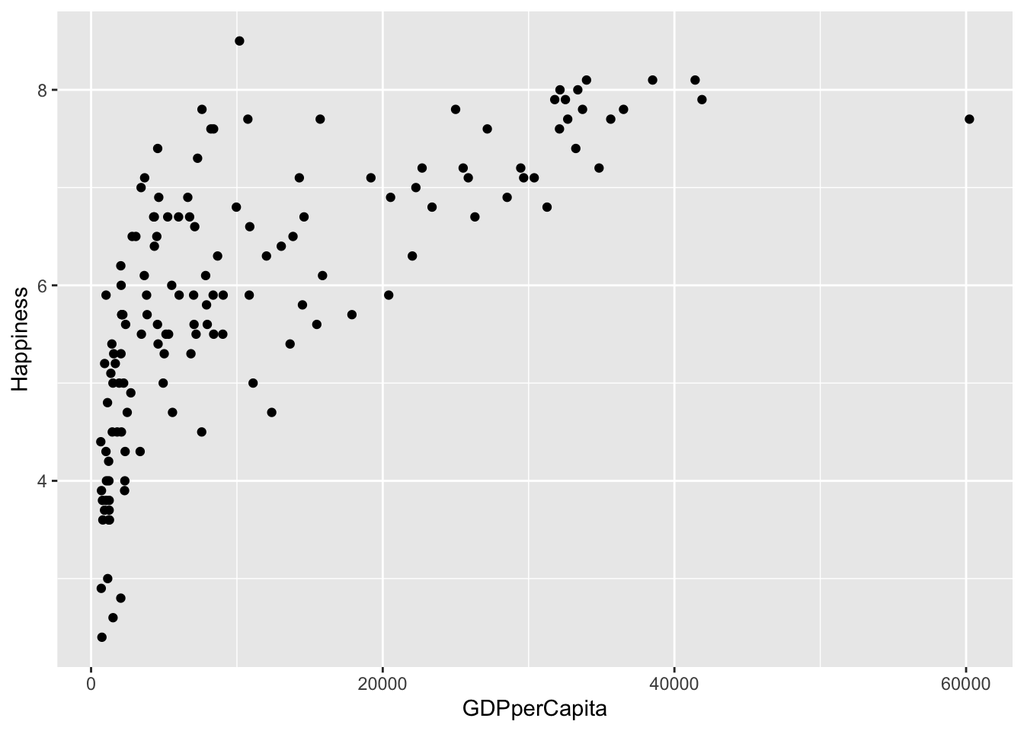

```r
ggplot(happy, aes(x=GDPperCapita, y=Happiness)) +
  geom_point()
```

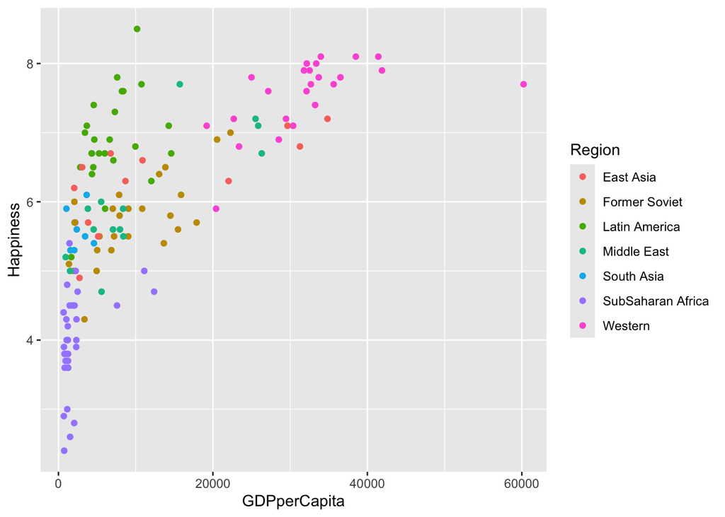

```r
ggplot(happy, aes(x=GDPperCapita, y=Happiness, color=Region)) +
  geom_point()
```

### Modify the following starter plot to change the color of all points to `"pink"`.

Hint: check out ?geom_point

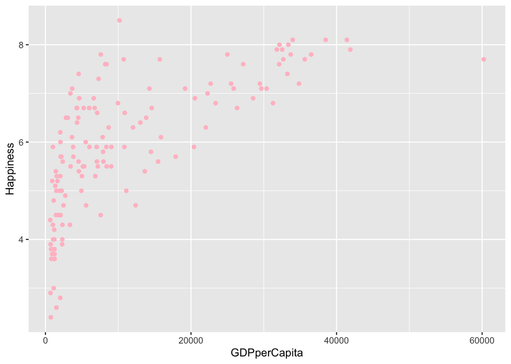

```r
ggplot(happy, aes(x = GDPperCapita, y = Happiness)) +
  geom_point(colour="pink")
```

### Since all the points are now pink, the effect of Region is no longer visible. Let’s add Region back in, and change the size of the points to reflect the population size.

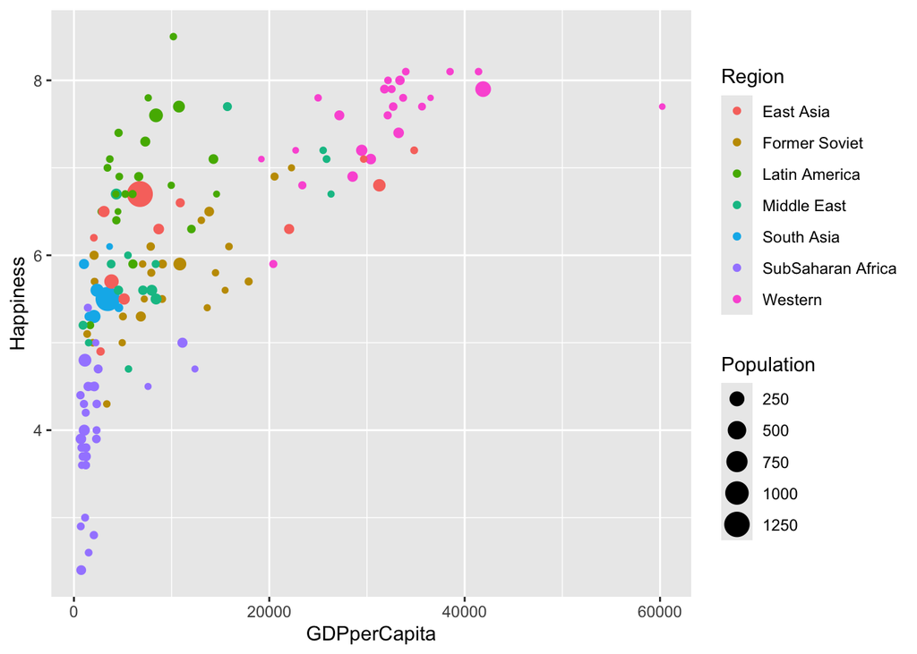

```r
ggplot(happy, aes(x = GDPperCapita, y = Happiness, color = Region, size = Population)) +
  geom_point()
```

### Add labels for title, x and y axes, and size of points. We’ll be more specific about what these things mean.

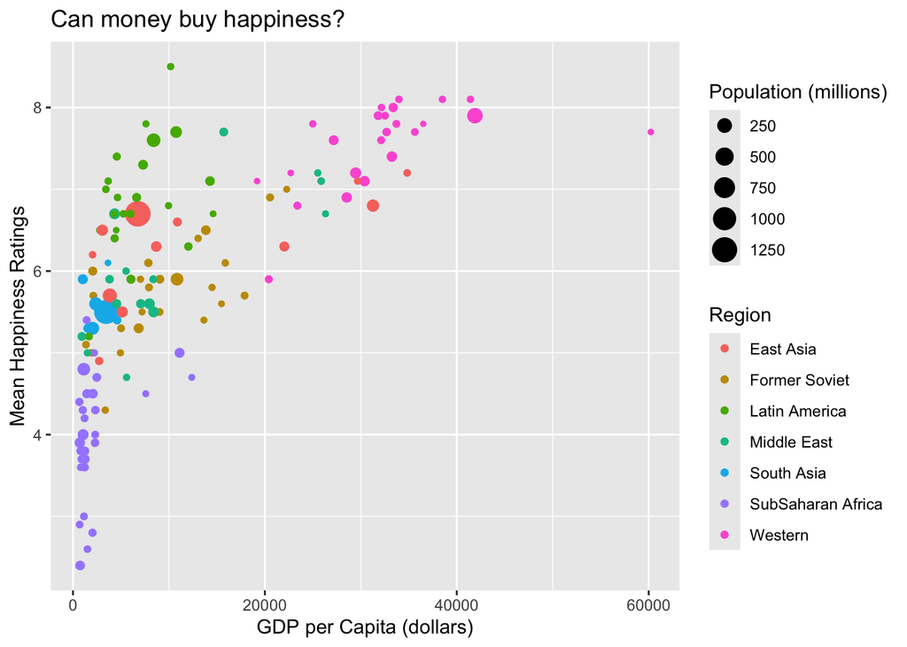

```r
ggplot(happy, aes(x = GDPperCapita, y = Happiness, , size = Population, color = Region)) +
  geom_point() +
  labs(
    title = "Can money buy happiness?",
    x = "GDP per Capita (dollars)",
    y = "Mean Happiness Ratings",
    size = "Population (millions)"
    )
```

### Does money buy happiness everywhere?

Group the data by Region and calculate the correlation between `Happiness` and `GDPperCapita`.

```r
happy %>%
  group_by(Region) %>%
  summarise(GDPvsHappiness = cor(Happiness, GDPperCapita)) #what's the problem with this table?
```

```
## # A tibble: 7 × 2
##   Region            GDPvsHappiness
##   <chr>                      <dbl>
## 1 East Asia                 0.699
## 2 Former Soviet            NA
## 3 Latin America             0.369
## 4 Middle East              NA
## 5 South Asia                0.0232
## 6 SubSaharan Africa         0.361
## 7 Western                   0.561
```

```r
happy %>%
  filter(!is.na(Happiness), !is.na(GDPperCapita)) %>%
  group_by(Region) %>%
  summarise(GDPvsHappiness = cor(Happiness, GDPperCapita))
```

```
## # A tibble: 7 × 2
##   Region            GDPvsHappiness
##   <chr>                      <dbl>
## 1 East Asia                 0.699
## 2 Former Soviet             0.676
## 3 Latin America             0.369
## 4 Middle East               0.744
## 5 South Asia                0.0232
## 6 SubSaharan Africa         0.361
## 7 Western                   0.561
```

### Is there an environmental cost of happiness?

Plot the relation between `Happiness` and `Footprint` (land and sea area required to produce the resources needed).

Then, calculate the correlation between `Happiness` and `Footprint` for each region. Hint: copy the correlation code above and change the relevant variables.

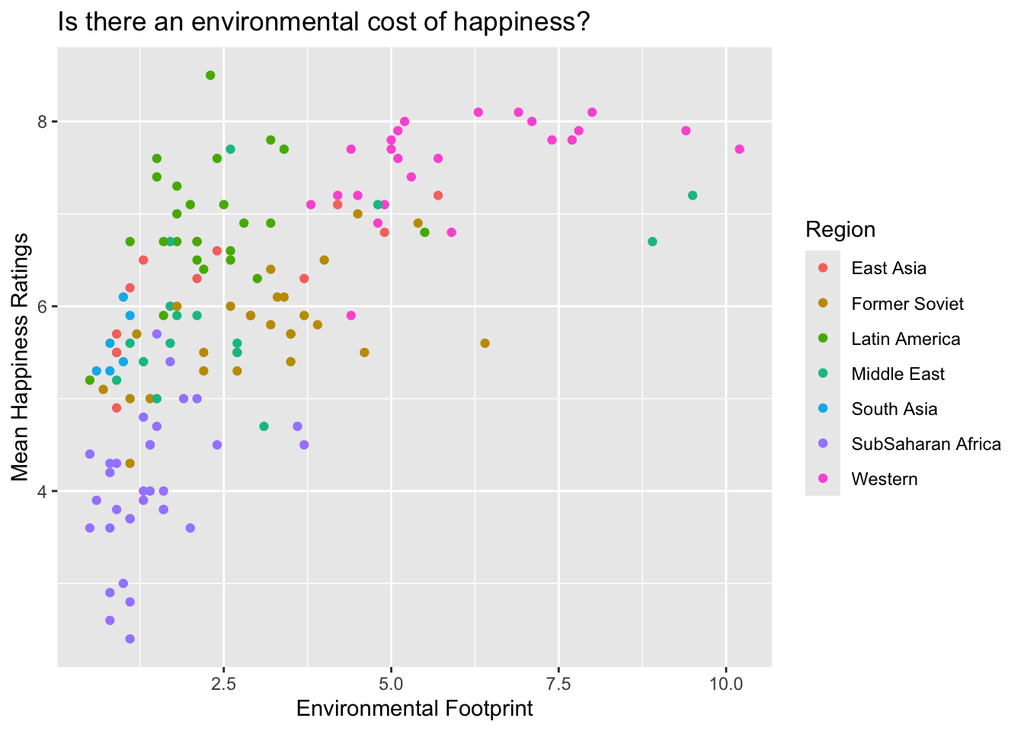

```r
happy %>%
  ggplot(aes(x = Footprint, y = Happiness, color = Region)) +
  geom_point() +
  labs(
    title = "Is there an environmental cost of happiness?",
    x = "Environmental Footprint",
    y = "Mean Happiness Ratings",
    color = "Region"
    )
```

```r
happy %>%
  filter(!is.na(Happiness), !is.na(Footprint)) %>%
  group_by(Region) %>%
  summarise(FootprintvsHappiness = cor(Happiness, Footprint))
```

```
## # A tibble: 7 × 2
##   Region            FootprintvsHappiness
##   <chr>                            <dbl>
## 1 East Asia                        0.768
## 2 Former Soviet                    0.599
## 3 Latin America                    0.262
## 4 Middle East                      0.545
## 5 South Asia                       0.674
## 6 SubSaharan Africa                0.416
## 7 Western                          0.505
```

# Your Turn!

### How many countries are developed? Make a bar plot of the distribution of `HDI_group`

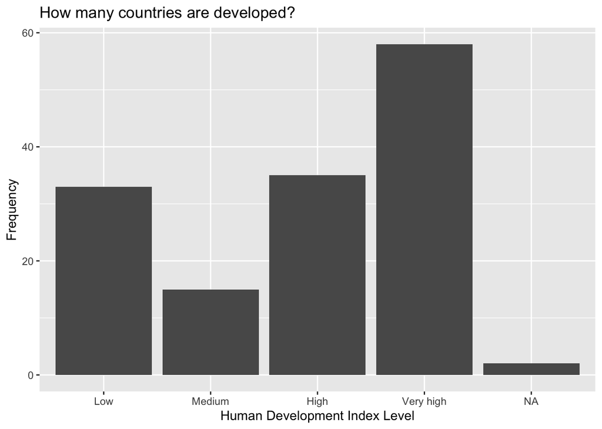

```r
ggplot(happy, aes(x=HDI_group)) +
  geom_bar() +
  labs(
    title = "How many countries are developed?",
    x = "Human Development Index Level",
    y = "Frequency"
    )
```

### Histogram

Pick a single numerical variable (any variable you choose from the data) and make a histogram of it.

(This time no starter code is provided, you’re on your own!)

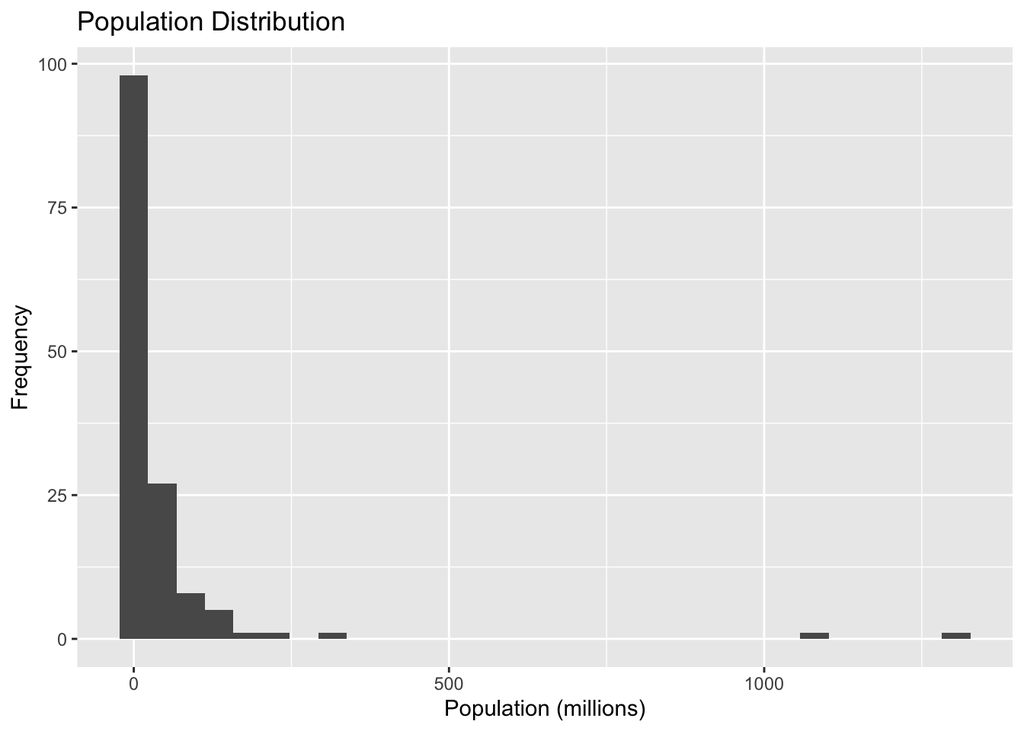

```r
ggplot(happy, aes(x=Population)) +
  geom_histogram() +
  labs(
    title = "Population Distribution",
    x = "Population (millions)",
    y = "Frequency"
    )
```

### Numerical data visualization

Pick a numerical variable and a visualization (you pick the type!) to visualize the relationship between this variable and `Region`. How would you interpret the visualization?

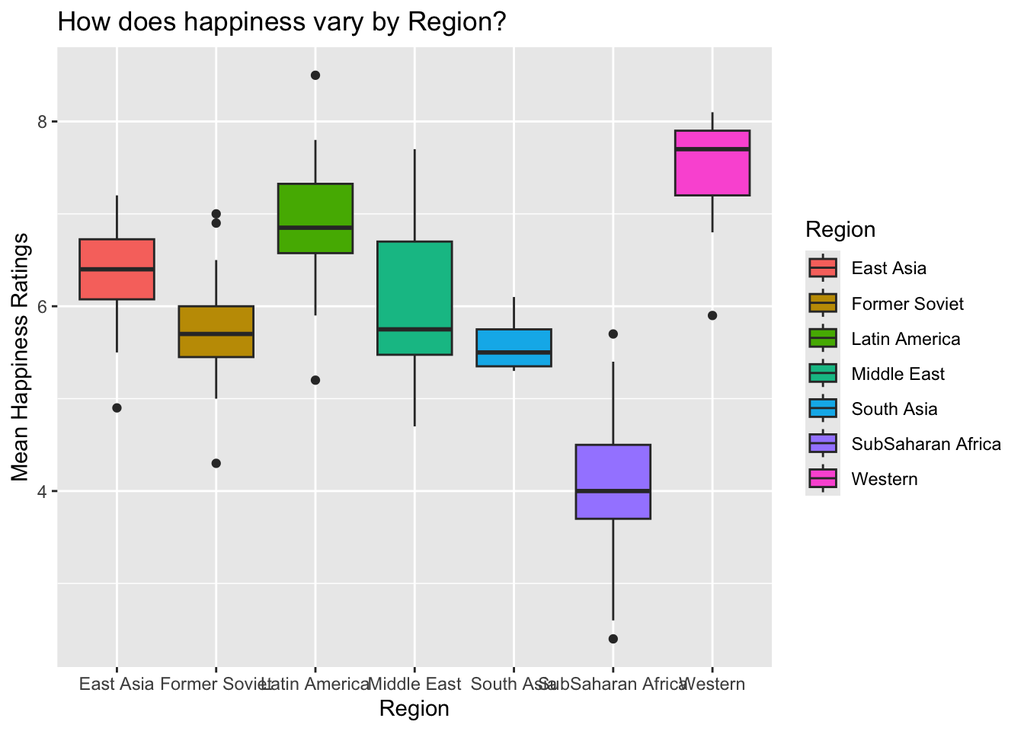

```r
happy %>%
  ggplot(aes(x = Region, y = Happiness, fill = Region)) +
  geom_boxplot() +
  labs(
    title = "How does happiness vary by Region?",
    x = "Region",
    y = "Mean Happiness Ratings",
    fill = "Region"
    )
```

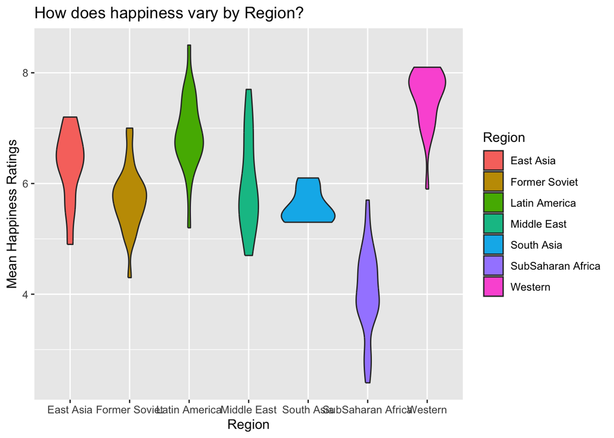

```r
happy %>%
  ggplot(aes(x = Region, y = Happiness, fill = Region)) +
  geom_violin() +
  labs(
    title = "How does happiness vary by Region?",
    x = "Region",
    y = "Mean Happiness Ratings",
    fill = "Region"
    )
```

### Categorical visualization

Focus on the two categorical variables of `Region` and `HDI_group` and make a visualization to visualize the relationship between them. How would you interpret the visualization?

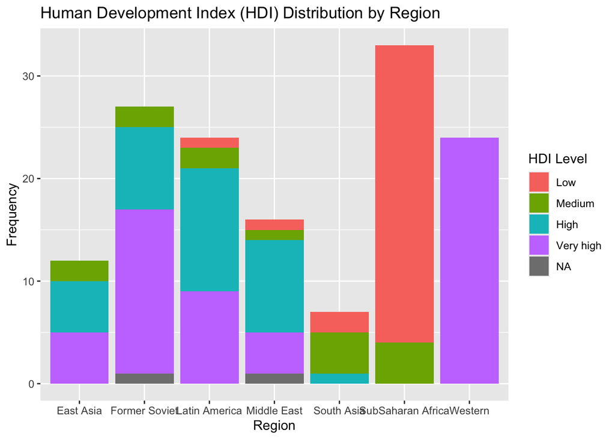

```r
happy %>%
  ggplot(aes(x = Region, fill = HDI_group)) +
  geom_bar() +
  labs(
    title = "Human Development Index (HDI) Distribution by Region",
    x = "Region",
    y = "Frequency",
    fill = "HDI Level"
    )
```

### Multivariate, numerical and categorical

Pick two numerical variables to consider alongside a categorical variable (either `Region` or `HDI_group`) and make a visualization that incorporates all of them. How would you interpret the visualization?

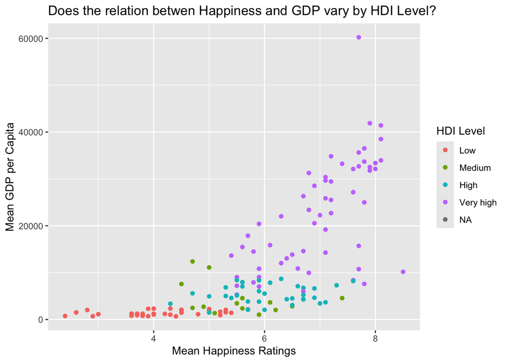

```r
happy %>%
  ggplot(aes(x = Happiness, y = GDPperCapita, color = HDI_group)) +
  geom_point() +
  labs(
    title = "Does the relation betwen Happiness and GDP vary by HDI Level?",
    x = "Mean Happiness Ratings",
    y = "Mean GDP per Capita",
    color = "HDI Level"
    )
```